# Quiz01

Ekaterina Bochvaroska - 89221049

2025-03-19

```r
my.data <- read.delim("~/quiz01/data.txt", header = TRUE, sep = "\t", stringsAsFactors = FALSE)
```

```r
x <- 9
z <- 4

my.data <- my.data[unique(c(seq(x, nrow(my.data), by = 10),
                            seq(z, nrow(my.data), by = 10))), ]
dim(my.data)
```

```
## [1] 105  25
```

### Questions:

*1.* *Draw histogram of the variable Books..how.many.per.year. What shape is your distribution? Report the appropriate central tendency measure and variability measure based on distribution shape. Justify your choice.*

Histogram of Books Read per Year

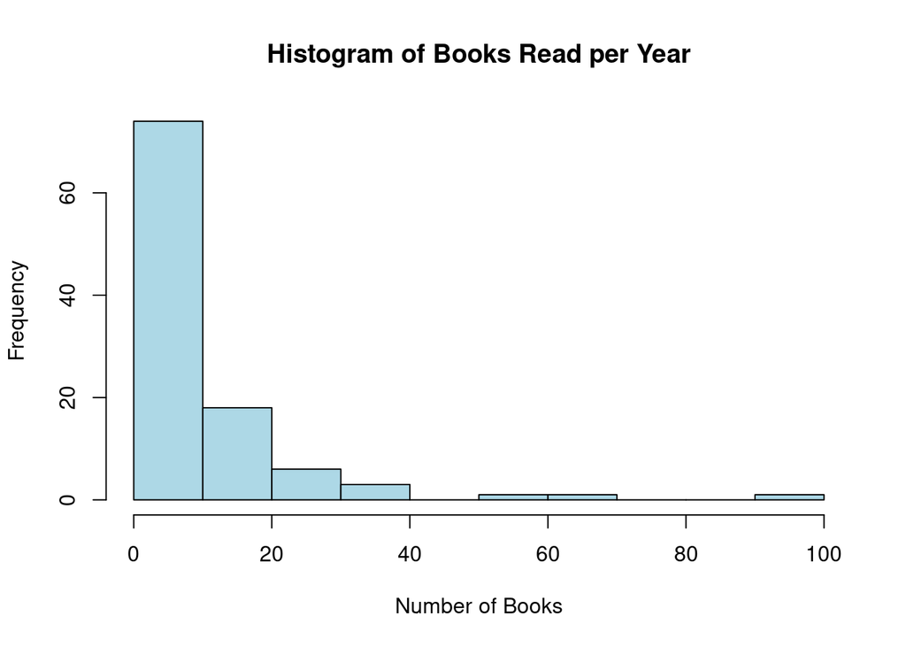

```r
hist(my.data$Books..how.many.per.year,
     main = "Histogram of Books Read per Year",
     xlab = "Number of Books",
     col = "lightblue",
     border = "black")
```

### Summary Statistics

```r
median_books <- median(my.data$Books..how.many.per.year, na.rm = TRUE)
iqr_books    <- IQR(my.data$Books..how.many.per.year, na.rm = TRUE)

cat("Median:", median_books, "\n")
```

```
## Median: 7
```

```r
cat("IQR:", iqr_books, "\n")
```

```
## IQR: 11
```

### Conclusion

The histogram of **Books..how.many.per.year** is right-skewed and asymmetric, with most students reading between 0 and 10 books, while a few read many more, creating a long right tail. Because the distribution is asymmetric, the **median (7 books)** is a better measure of central tendency than the mean, and the **IQR (11 books)** better describes the variability by focusing on the middle 50% of the data, unaffected by the extreme values.

*2.* *Draw boxplot for the variable Friends.on.Facebook. Report all the crucial values from the graph and interpret them. Do you see any outliers? Explain the term.*

### Boxplot of Friends.on.Facebook

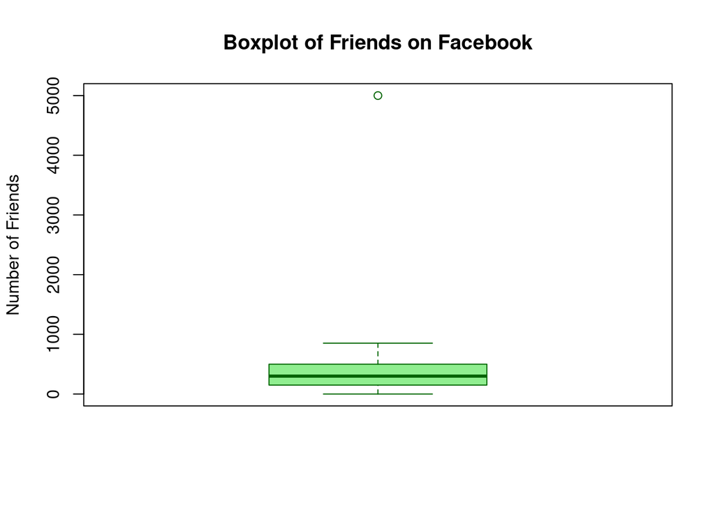

```r
boxplot(my.data$Friends.on.Facebook,
        main = "Boxplot of Friends on Facebook",
        ylab = "Number of Friends",
        col = "lightgreen",
        border = "darkgreen")
```

```r
summary_friends <- summary(my.data$Friends.on.Facebook)
iqr_friends <- IQR(my.data$Friends.on.Facebook, na.rm = TRUE)

cat("Summary statistics for Friends.on.Facebook:\n")
```

```
## Summary statistics for Friends.on.Facebook:
```

```r
print(summary_friends)
```

```
##    Min. 1st Qu.  Median    Mean 3rd Qu.    Max.    NA's
##     0.0   150.0   300.0   417.1   487.5  5000.0      55
```

```r
cat("IQR:", iqr_friends, "\n")
```

```
## IQR: 337.5
```

The boxplot displays:

- The **median** (the central line inside the box) represents the 50th percentile; half of the observations have a lower number of friends, and half have a higher number.
- The **lower quartile (Q1)** and **upper quartile (Q3)** (the edges of the box) indicate that 25% of the data falls below Q1 and 25% is above Q3.
- The **IQR** is the difference between Q3 and Q1, showing the range of the middle 50% of the data.
- The **whiskers** extend to the most extreme data points within 1.5 * IQR from the quartiles. These points beyond the whiskers are considered **outliers**.

An **outlier** is an observation that is significantly higher or lower than the rest of the data. Outliers can indicate variability in the data, errors in data collection, or exceptions in this case for example *individuals with* an exceptionally high or low number of Facebook friends compared to most of the sample.

**3.**Write function dependable of r and will return circumference of a circle with radius r. Compute the circumference of the circle, here r = x (x is the last digit of your student number).

```r
circumference <- function(r) {
  2 * pi * r
}

x <- 9

circ_value <- round(circumference(x), 2)

cat("Radius:", x, "\n")
```

```
## Radius: 9
```

```r
cat("Circumference:", circ_value, "\n")
```

```
## Circumference: 56.55
```

**4.**Suppose you have played the roulette x5-times (if your x = 1, this means 15 times) and you have placed the bet on the number 17 every time. This means the probability of winning is 1/37 for one roll. Compute probability P(X = z). Draw the probability function and cumulative probability function for the above case. Compute the probability of winning less than 5 times.

```r
x <- 9
n <- 10 * x + 5
p <- 1/37
z <- 4

prob_z <- dbinom(z, size = n, prob = p)
# P(X < 5) = P(X <= 4)
prob_less_than_5 <- pbinom(4, size = n, prob = p)

# Round probabilities to two decimals
prob_z_r <- round(prob_z, 2)
prob_less_than_5_r <- round(prob_less_than_5, 2)

cat("Probability of ", z, "wins:", prob_z_r, "\n")
```

```
## Probability of  4 wins: 0.14
```

```r
cat("Probability of winning less than 5 times:", prob_less_than_5_r, "\n")
```

```
## Probability of winning less than 5 times: 0.88
```

### PMF Plot

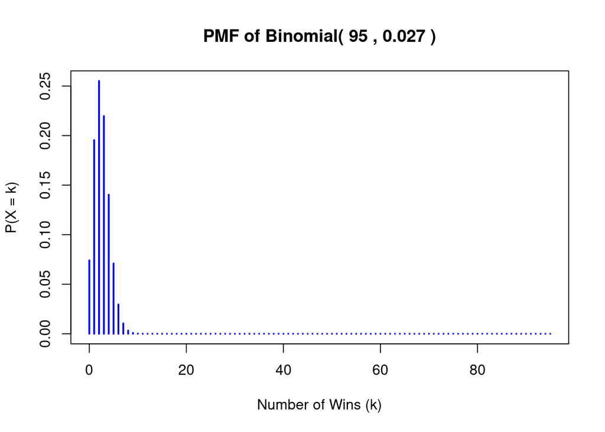

```r
# A sequence of possible wins from 0 to n
k_values <- 0:n

# PMF values: P(X = k)
pmf_values <- dbinom(k_values, size = n, prob = p)

plot(k_values, pmf_values,
     type = "h",
     main = paste("PMF of Binomial(", n, ",", round(p,4), ")"),
     xlab = "Number of Wins (k)",
     ylab = "P(X = k)",
     col = "blue",
     lwd = 2)
```

### CDF Plot

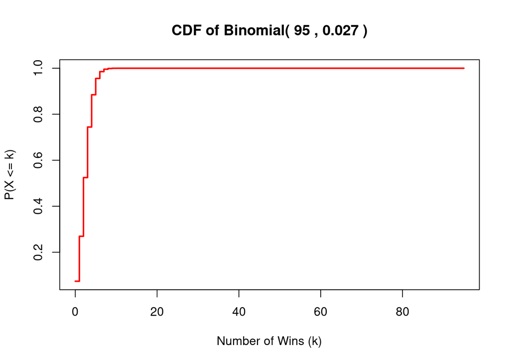

```r
# CDF values: P(X <= k)
cdf_values <- pbinom(k_values, size = n, prob = p)

plot(k_values, cdf_values,
     type = "s",
     main = paste("CDF of Binomial(", n, ",", round(p,4), ")"),
     xlab = "Number of Wins (k)",
     ylab = "P(X <= k)",
     col = "red",
     lwd = 2)
```